# Predicting Correct Weight Usage

## Abstract

Weight lifting data is analyzed using a Random Forest in order to predict whether participants were lifting barbells correctly or incorrectly using accelerometer data.

## Data

The data used for this exercise was collected by [Groupware Human Activity Recognition](http://groupware.les.inf.puc-rio.br/har) project. Class A corresponds to correct lifting, the other 4 classes (B-E) to various common mistakes (see the previous link for more details). The first step is to download the data, if necessary.

```r
getdata <- function(filename, url) {
    if (!file.exists("data")) dir.create("data")
    fullfile <- paste("data", filename, sep="/")
    if (!file.exists(fullfile)) { download.file(url, destfile=fullfile, method="curl")}
    fullfile
}
training.file <- getdata("pml-training.csv", "https://d396qusza40orc.cloudfront.net/predmachlearn/pml-training.csv")
test.file <- getdata("pml-testing.csv", "https://d396qusza40orc.cloudfront.net/predmachlearn/pml-testing.csv")
```

Next load the data. There are a number of ‘non-standard’ NA values present.  
To keep the analysis simple, any column with any NA values present is removed rather than attempting to impute their values. The first seven columns contain information like the users name and date. While these might improve the classification on the training set, they are unlikely to generalize and hence are removed. The random forest training is faster if the data is converted into matrices.

```r
X.train <- read.csv(training.file, na.strings = c("", "NA", "#DIV/0!"))
X.test <- read.csv(test.file, na.strings = c("", "NA", "#DIV/0!"))
y.train <- X.train[,160]
X.train <- X.train[,-c(1:7, 160)]
X.test <- X.test[,-c(1:7, 160)]
goodCols <- (colSums(is.na(X.train)) == 0) & (colSums(is.na(X.test)) == 0)
X.train <- as.matrix(X.train[, goodCols])
X.test <- as.matrix(X.test[, goodCols])
```

leaving 52 features to train the model on.

## Training the Model

The model used for this project is a Random Forest, which is computationally expensive but often has good performance. This already can use out-of-bag to provide an unbiased error estimate, so in principle cross-validation is not necessary. However, for pedagogical purposes it is interesting to seperate out a validation sample (40% of the training set) and test the prediction accuracy using that.

The settings for the forest (number of trees, number of tries) are set by exploratory analysis using the training and validation sets. A larger number of trees or tries does not seem to improve the performance on either (which is already excellent; see below), and significantly increases the computational expense. This process is not shown here because it was quite expensive to compute with more trees or tries.

```r
library(caret, quietly=TRUE)
set.seed(838341)
inTrain <- createDataPartition(y=y.train, p=0.6, list=FALSE)
X.trainBase <- X.train[inTrain,]
y.trainBase <- y.train[inTrain]
modFit <- train(X.trainBase, y.trainBase, method="rf", ntree=250,
                tuneGrid=data.frame(mtry=8), importance=TRUE)
```

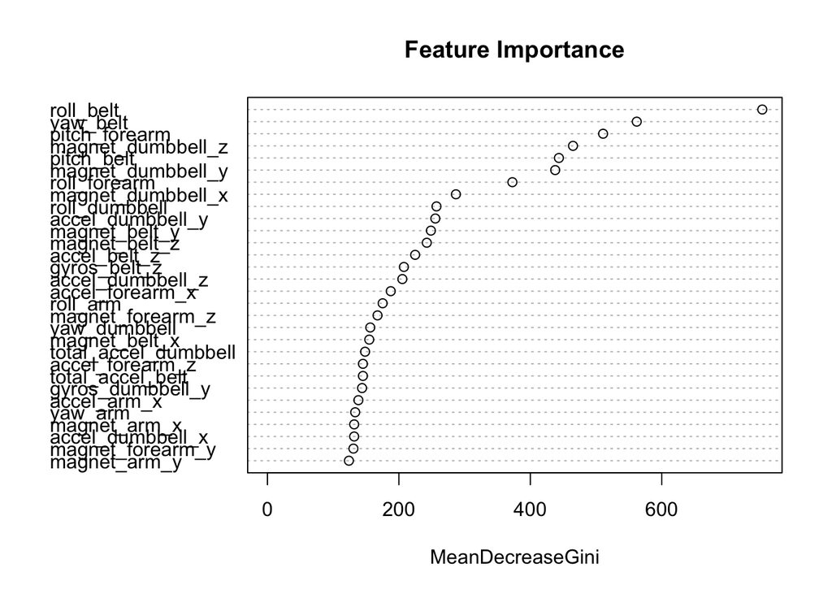

```r
varImpPlot(modFit$finalModel, sort=TRUE, type=2, pch=21,
           main="Feature Importance")
```

```r
print(modFit$results)
```

```
##   mtry  Accuracy     Kappa  AccuracySD     KappaSD
## 1    8 0.9894177 0.9866104 0.001718294 0.002170603
```

The training accuracy is quite good (about 99%), and the roll of the belt is the most useful predictor.

## Evaluation of the Model

Now look at the validation set confusion matrix:

```r
pred <- predict(modFit, X.train[-inTrain,])
conf <- confusionMatrix(y.train[-inTrain], pred, dnn=c("Predicted", "True"))
print(conf$table)
```

```
##          True
## Predicted    A    B    C    D    E
##         A 2225    5    0    0    2
##         B   18 1499    1    0    0
##         C    0    3 1363    2    0
##         D    0    0   14 1272    0
##         E    0    0    2    4 1436
```

The model works extremely well on the validation sample as well, with an accuracy (per class) of 0.995, 0.996, 0.993, 0.997, 0.999. This can also be examined visually.

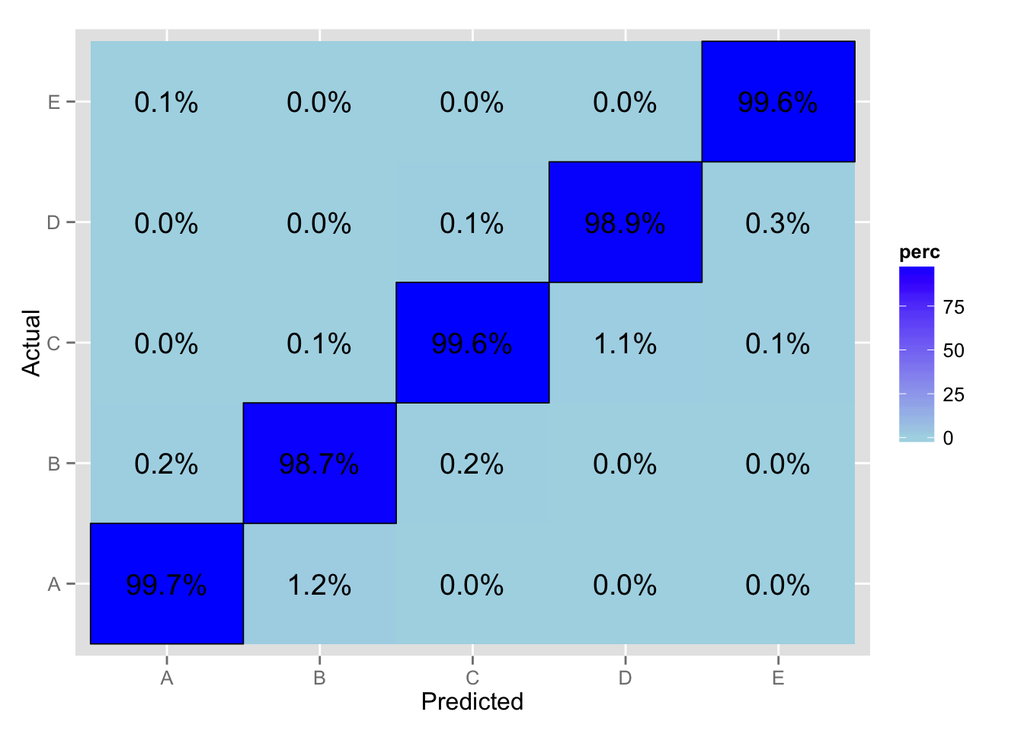

```r
conf.percent <- expand.grid(x=rownames(conf$table), y=colnames(conf$table))
conf.percent$perc <- as.vector(100 * conf$table / rowSums(conf$table))
p <- ggplot(conf.percent, aes(x=x, y=y, fill=perc,
                        label=sprintf("%1.1f%%", perc)),
            color="black", size=0.1) +
    geom_tile() + labs(x="Predicted",y="Actual") +
    scale_fill_gradient(low="light blue", high="blue") +
    geom_tile(aes(x=x,y=y),data=subset(conf.percent, x==y),
              color="black",size=0.3, fill="black", alpha=0)
p + geom_text()
```

## Predictions

Here are the predicted values for the test set:

```r
print(predict(modFit, X.test))
```

```
##  [1] B A B A A E D B A A B C B A E E A B B B
## Levels: A B C D E
```

which can be written out for submission.

```r
pml_write_files = function(x, dir){
  n = length(x)
  if (!file.exists(dir)) dir.create(dir)
  for(i in 1:n){
    filename = paste(dir, paste0("problem_id_",i,".txt"), sep="/")
    write.table(x[i],file=filename,quote=FALSE,row.names=FALSE,col.names=FALSE)
  }
}
pml_write_files(predict(modFit, X.test), "results")
```